# US AIRLINE DATA ANALYSIS

Author:Moreen Owino

This data analysis is done to aid an airline company looking to enter the United States domestic market which has identified medium and large airports as their desired operating locations. The company believes that it has a competitive advantage in maintaining punctuality, so it plans on making this a big part of its brand image with a motto, “On time, for you.” To kick start operations, the company has decided to start with 5 round trip routes.

The analysis aims to analyze 1Q2000 data and identify:

1. The 6 busiest round trip routes in terms of number of round trip flights in the quarter. Excluding canceled flights.
2. The 6 most profitable round trip routes (without considering the upfront airplane cost) in the quarter. Along with the profit, showing total revenue, total cost, summary values of other key components and total round trip flights in the quarter for the top 6 most profitable routes. Excluding canceled flights.
3. The 5 round trip routes that i recommend to invest in based on any factors that i choose.
4. The number of round trip flights it will take to breakeven on the upfront airplane cost for each of the 5 round trip routes that you recommend. showing key summary components for these routes.
5. Key Performance Indicators (KPI’s) that i recommend tracking in the future to measure the success of the round trip routes that i recommend.
6. My conclusion and recommendations.

**Importing required libraries and loading data**

```python
# importing libraries

import pandas as pd
import numpy as np
import matplotlib.pyplot as plt
import seaborn as sns
import plotly.express as px
```

```python
# Loading in data sets
# trying not to hardcode importation and allow importation of similar data sets with different file names
# creating function that loads CSV files

def load_csv(file):
    """
    Load a dataset from a CSV file.

    Args:
        file: A CSV file.

    Returns:
        pd.DataFrame: The loaded dataset as a Pandas DataFrame.

    Raises:
        FileNotFoundError: If the specified file does not exist.
    """
    try:
        # Load the dataset from the specified file
        dataset = pd.read_csv(file)
        return dataset
    except FileNotFoundError:
        raise FileNotFoundError(f"File not found: {file}")


# Load the Flights dataset
flights_df = load_csv('Flights.csv')

# Load the Tickets dataset
tickets_df = load_csv('Tickets.csv')

# Load the Airport Codes dataset
airportcode_df = load_csv('Airport_Codes.csv')
```

## Quality Checks

Next we'll check the data quality by trying to understand our data and finding out if there are any outliers , missing values, duplicates, data types and also getting data summaries.

**1. Checking contents of data sets**

We'll start by checking the contents of each file to get an idea of what each contains

```python
# First we check the contents of each file by printing the first five rows of each data set to get an idea of what they have

# Check the first few rows of each dataset and the shape
# we create a function to do this as below

def display_data_info(data_df, data_name):
    """
    Display the first few rows and shape of a dataset.

    Args:
        data_df (pd.DataFrame): The dataset as a Pandas DataFrame.
        data_name (str): A label for the dataset.

    Returns:
        None
    """
    print(f"{data_name} data set\n\n", data_df.head(), f"{data_name} Data Shape:", data_df.shape)
    print("\n\n")
```

```python
# Using the function
# Specify the dataframes and their names
datasets = [
    (flights_df, "Flights"),
    (tickets_df, "Tickets"),
    (airportcode_df, "Airportcodes")
]

# Display information for each dataset using the function
for data_df, data_name in datasets:
    display_data_info(data_df, data_name)
```

```
Flights data set

       FL_DATE OP_CARRIER TAIL_NUM OP_CARRIER_FL_NUM  ORIGIN_AIRPORT_ID ORIGIN  \
0  2019-03-02         WN   N955WN              4591              14635    RSW
1  2019-03-02         WN   N8686A              3231              14635    RSW
2  2019-03-02         WN   N201LV              3383              14635    RSW
3  2019-03-02         WN   N413WN              5498              14635    RSW
4  2019-03-02         WN   N7832A              6933              14635    RSW

  ORIGIN_CITY_NAME  DEST_AIRPORT_ID DESTINATION DEST_CITY_NAME  DEP_DELAY  \
0   Fort Myers, FL            11042         CLE  Cleveland, OH       -8.0
1   Fort Myers, FL            11066         CMH   Columbus, OH        1.0
2   Fort Myers, FL            11066         CMH   Columbus, OH        0.0
3   Fort Myers, FL            11066         CMH   Columbus, OH       11.0
4   Fort Myers, FL            11259         DAL     Dallas, TX        0.0

   ARR_DELAY  CANCELLED AIR_TIME DISTANCE  OCCUPANCY_RATE
0       -6.0        0.0    143.0   1025.0            0.97
1        5.0        0.0    135.0    930.0            0.55
2        4.0        0.0    132.0    930.0            0.91
3       14.0        0.0    136.0    930.0            0.67
4      -17.0        0.0    151.0   1005.0            0.62   Flights Data Shape: (1915886, 16)



Tickets data set

         ITIN_ID  YEAR  QUARTER ORIGIN ORIGIN_COUNTRY ORIGIN_STATE_ABR  \
0  201912723049  2019        1    ABI             US               TX
1  201912723085  2019        1    ABI             US               TX
2  201912723491  2019        1    ABI             US               TX
3  201912723428  2019        1    ABI             US               TX
4  201912723509  2019        1    ABI             US               TX

  ORIGIN_STATE_NM  ROUNDTRIP REPORTING_CARRIER  PASSENGERS ITIN_FARE  \
0           Texas        1.0                MQ         1.0     736.0
1           Texas        1.0                MQ         1.0     570.0
2           Texas        1.0                MQ         1.0     564.0
3           Texas        1.0                MQ         1.0     345.0
4           Texas        0.0                MQ         1.0     309.0
```

[output cut: 10 more lines]

```
Airportcodes data set

             TYPE                                NAME  ELEVATION_FT CONTINENT  \
0       heliport                   Total Rf Heliport          11.0       NaN
1  small_airport                Aero B Ranch Airport        3435.0       NaN
2  small_airport                        Lowell Field         450.0       NaN
3  small_airport                        Epps Airpark         820.0       NaN
4         closed  Newport Hospital & Clinic Heliport         237.0       NaN

  ISO_COUNTRY  MUNICIPALITY IATA_CODE                            COORDINATES
0          US      Bensalem       NaN     -74.93360137939453, 40.07080078125
1          US         Leoti       NaN                 -101.473911, 38.704022
2          US  Anchor Point       NaN            -151.695999146, 59.94919968
3          US       Harvest       NaN  -86.77030181884766, 34.86479949951172
4          US       Newport       NaN                    -91.254898, 35.6087   Airportcodes Data Shape: (55369, 8)
```

**3. Checking the data types**

```python
# creating function
def display_data_type(data_df, data_name):
    """
    Display information about a dataset using the .info() method.

    Args:
        data_df (pd.DataFrame): The dataset as a Pandas DataFrame.
        data_name (str): A label for the dataset.

    Returns:
        None
    """
    print(f"{data_name} Data Info:\n", data_df.info())
    print("\n\n")
```

```python
# checking the data types

# Specify the dataframes and their names in a list
datasets = [
    (flights_df, "Flights"),
    (tickets_df, "Tickets"),
    (airportcode_df, "Airport Codes")
]

# Display information for each dataset
for data_df, data_name in datasets:
    display_data_type(data_df, data_name)
```

```
<class 'pandas.core.frame.DataFrame'>
RangeIndex: 1915886 entries, 0 to 1915885
Data columns (total 16 columns):
 #   Column             Dtype
---  ------             -----
 0   FL_DATE            object
 1   OP_CARRIER         object
 2   TAIL_NUM           object
 3   OP_CARRIER_FL_NUM  object
 4   ORIGIN_AIRPORT_ID  int64
 5   ORIGIN             object
 6   ORIGIN_CITY_NAME   object
 7   DEST_AIRPORT_ID    int64
 8   DESTINATION        object
 9   DEST_CITY_NAME     object
 10  DEP_DELAY          float64
 11  ARR_DELAY          float64
 12  CANCELLED          float64
 13  AIR_TIME           object
 14  DISTANCE           object
 15  OCCUPANCY_RATE     float64
dtypes: float64(4), int64(2), object(10)
memory usage: 233.9+ MB
Flights Data Info:
 None



<class 'pandas.core.frame.DataFrame'>
RangeIndex: 1167285 entries, 0 to 1167284
Data columns (total 12 columns):
 #   Column             Non-Null Count    Dtype
---  ------             --------------    -----
 0   ITIN_ID            1167285 non-null  int64
 1   YEAR               1167285 non-null  int64
 2   QUARTER            1167285 non-null  int64
 3   ORIGIN             1167285 non-null  object
 4   ORIGIN_COUNTRY     1167285 non-null  object
 5   ORIGIN_STATE_ABR   1167285 non-null  object
 6   ORIGIN_STATE_NM    1167285 non-null  object
```

[output cut: 14 more lines]

```
Data columns (total 8 columns):
 #   Column        Non-Null Count  Dtype
---  ------        --------------  -----
 0   TYPE          55369 non-null  object
 1   NAME          55369 non-null  object
 2   ELEVATION_FT  48354 non-null  float64
 3   CONTINENT     27526 non-null  object
 4   ISO_COUNTRY   55122 non-null  object
 5   MUNICIPALITY  49663 non-null  object
 6   IATA_CODE     9182 non-null   object
 7   COORDINATES   55369 non-null  object
dtypes: float64(1), object(7)
memory usage: 3.4+ MB
Airport Codes Data Info:
 None
```

From the data set information printed above it is apparent that some data types need to be changed to the correct format inorder to aid in down stream analysis.For example Distance is listed as data type object yet we need it to be in numeric type to aid in calculations we will do for the analysis.So we will change some of the data types as shown below

```python
# Convert data types in the Flights dataset
# errors='coerce' used to handle conversion errors and replace them with NaN values if not converted to the specified data type

flights_df['FL_DATE'] = pd.to_datetime(flights_df['FL_DATE']) # converting to date time
flights_df['AIR_TIME'] = pd.to_numeric(flights_df['AIR_TIME'], errors='coerce')# converting to numeric
flights_df['DISTANCE'] = pd.to_numeric(flights_df['DISTANCE'], errors='coerce')
flights_df['CANCELLED'] = flights_df['CANCELLED'].astype(int)# converting to type integer
flights_df['ORIGIN_AIRPORT_ID'] = flights_df['ORIGIN_AIRPORT_ID'].astype(int)
flights_df['DEST_AIRPORT_ID'] = flights_df['DEST_AIRPORT_ID'].astype(int)

# Convert data types in the Tickets dataset
# Noted that there are some values like 820$$$ in the ITIN_FARE colunm that are causing errors when trying to convert to numeric
# 1. Data Cleaning: Remove non-numeric characters like $$$ from 'ITIN_FARE that were preventing conversion to numeric'
tickets_df['ITIN_FARE'] = tickets_df['ITIN_FARE'].str.replace('[^\d.]', '', regex=True)

# 2. Convert the 'ITIN_FARE' column to numeric
tickets_df['ITIN_FARE'] = pd.to_numeric(tickets_df['ITIN_FARE'], errors='coerce')# converting to numeric

tickets_df['ROUNDTRIP'] = tickets_df['ROUNDTRIP'].astype(int)# converting to type integer
tickets_df['PASSENGERS'] = pd.to_numeric(tickets_df['PASSENGERS'], errors='coerce')# converting to numeric

# Convert data types in the Airport Codes dataset
airportcode_df['ELEVATION_FT'] = pd.to_numeric(airportcode_df['ELEVATION_FT'], errors='coerce')

# Define a function to parse coordinates and create separate columns for latitude and longitude that we might use to map.
def parse_coordinates(coordinates):
    # Split the string into latitude and longitude
    lat_str, lon_str = coordinates.split(', ')
    # Convert to float
    return pd.Series({'LATITUDE': float(lat_str), 'LONGITUDE': float(lon_str)})

# Apply the function and create separate columns
airportcode_df[['LATITUDE', 'LONGITUDE']] = airportcode_df['COORDINATES'].apply(parse_coordinates)
```

**4. Outliers**

Next we will check each of the data sets for outliers.To do this we create a function *describe_dataset* that will help us get summary data on the data sets.

```python
# Define a function to load and describe a dataset
def describe_dataset(data_file, dataset_name):
    # Load the dataset into a DataFrame
    df = data_file

    # Display summary statistics using describe
    print(f"Summary statistics for the {dataset_name} dataset:")
    print("\n")
    print(df.describe())
    print("\n\n")

describe_dataset(flights_df, 'Flights data')
describe_dataset(tickets_df, 'tickets data')
describe_dataset(airportcode_df, 'airportcode data')
```

```
Summary statistics for the Flights data dataset:


       ORIGIN_AIRPORT_ID  DEST_AIRPORT_ID     DEP_DELAY     ARR_DELAY  \
count       1.915886e+06     1.915886e+06  1.865535e+06  1.859895e+06
mean        1.268815e+04     1.268927e+04  1.080275e+01  5.648737e+00
std         1.521900e+03     1.521249e+03  5.016305e+01  5.241170e+01
min         1.013500e+04     1.013500e+04 -6.300000e+01 -9.400000e+01
25%         1.129200e+04     1.129200e+04 -6.000000e+00 -1.500000e+01
50%         1.288900e+04     1.288900e+04 -2.000000e+00 -6.000000e+00
75%         1.405700e+04     1.405700e+04  7.000000e+00  8.000000e+00
max         1.621800e+04     1.621800e+04  2.941000e+03  2.923000e+03

          CANCELLED      AIR_TIME      DISTANCE  OCCUPANCY_RATE
count  1.915886e+06  1.857425e+06  1.913146e+06    1.915576e+06
mean   2.694002e-02  1.093854e+02  7.683305e+02    6.502339e-01
std    1.619082e-01  7.047085e+01  5.802869e+02    2.019994e-01
min    0.000000e+00 -1.210000e+02 -1.947000e+03    3.000000e-01
25%    0.000000e+00  5.900000e+01  3.420000e+02    4.800000e-01
50%    0.000000e+00  9.100000e+01  6.060000e+02    6.500000e-01
75%    0.000000e+00  1.390000e+02  1.010000e+03    8.247386e-01
max    1.000000e+00  2.222000e+03  9.898000e+03    1.000000e+00



Summary statistics for the tickets data dataset:


            ITIN_ID       YEAR    QUARTER     ROUNDTRIP    PASSENGERS  \
count  1.167285e+06  1167285.0  1167285.0  1.167285e+06  1.165308e+06
mean   1.715602e+11     2019.0        1.0  6.070497e-01  2.070102e+00
std    6.834957e+10        0.0        0.0  4.884062e-01  5.840215e+00
min    2.019120e+05     2019.0        1.0  0.000000e+00  1.000000e+00
25%    2.019115e+11     2019.0        1.0  0.000000e+00  1.000000e+00
50%    2.019128e+11     2019.0        1.0  1.000000e+00  1.000000e+00
75%    2.019140e+11     2019.0        1.0  1.000000e+00  1.000000e+00
max    2.019153e+11     2019.0        1.0  1.000000e+00  7.690000e+02

          ITIN_FARE
count  1.166325e+06
mean   4.077713e+02
std    7.766228e+02
min    0.000000e+00
25%    2.050000e+02
50%    3.480000e+02
75%    5.280000e+02
max    3.774000e+05



Summary statistics for the airportcode data dataset:


       ELEVATION_FT      LATITUDE     LONGITUDE
count  48354.000000  55369.000000  55369.000000
mean    1245.485068    -35.264176     25.730078
std     1608.475573     79.575124     27.203629
min    -1266.000000   -179.876999    -90.000000
25%      205.000000    -92.072403      8.276667
50%      720.000000    -72.128889     36.495633
75%     1500.000000     14.649167     43.780201
max    22000.000000    179.975700     82.750000
```

From the above output we can see that there are a couple of columns that are key in the analysis and have outliers and need to be dealt with namely:

**Tickets data set**

The ITIN_FARE has some very low minimums of about 0 which is quite abnormal for a flight to cost 0 dollars and some very high values such as the max of 377400.

**Flights data set**

The Distance variable also has some very low minimum values in the negatives and the maximumm also seems abit high.

Lets create a function *draw_box_plot* to plot some box plots for some clearer observation into the distribution of the data.

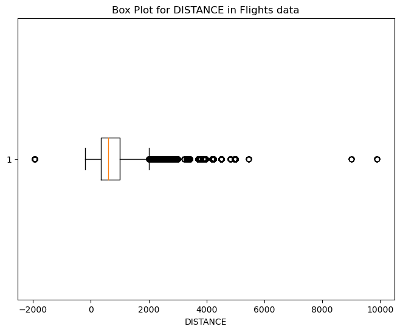

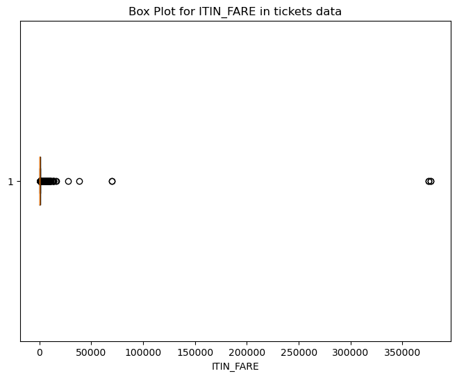

```python
# Define a function to draw box plots
def draw_box_plot(data, column_name, dataset_name):
    plt.figure(figsize=(8, 6))
    plt.boxplot(data[column_name].dropna(), vert=False)
    plt.title(f"Box Plot for {column_name} in {dataset_name}")
    plt.xlabel(column_name)
    plt.show()

 # plotting the box plots
draw_box_plot(flights_df, 'DISTANCE', 'Flights data')
draw_box_plot(tickets_df, 'ITIN_FARE', 'tickets data')
```

The box plots above confirm that there are indeed outliers so we go ahead and handle them below by creating a function called remove_outliers_iqr which uses the IQR method to detect and remove outliers.

```python
# creating function to remove and detect outliers

def remove_outliers_iqr(dataframe, column_name, lower_threshold, upper_threshold):
    """
    Remove outliers from a DataFrame column using the IQR method.

    Parameters:
    - dataframe: The DataFrame containing the data.
    - column_name: The name of the column with outliers.
    - threshold: The IQR threshold for identifying outliers. Default is 1.5.

    Returns:
    - A new DataFrame with outliers removed.
    """
    Q1 = dataframe[column_name].quantile(0.25)
    Q3 = dataframe[column_name].quantile(0.75)
    IQR = Q3 - Q1
    lower_bound = Q1 - lower_threshold * IQR
    upper_bound = Q3 + upper_threshold * IQR
    return dataframe[(dataframe[column_name] >= lower_bound) & (dataframe[column_name] <= upper_bound)]

# Remove outliers in the 'ITIN_FARE' column using the function
# the itin_fare seems to have some pretty low values and some very high values too as seen in the output from describe func

tickets_df = remove_outliers_iqr(tickets_df,'ITIN_FARE', lower_threshold = 0.06 ,upper_threshold = 22 )

flights_df = remove_outliers_iqr(flights_df,'DISTANCE', lower_threshold = 0.05 , upper_threshold = 7)
```

**6. Null or missing values**

Next we check for missing values in the data sets. We'll create a function to make the process easier and modular

```python
# creating function
def display_null_values(data_df, data_name):
    """
    Calculate and display null values for a dataset.

    Args:
        data_df (pd.DataFrame): The dataset as a Pandas DataFrame.
        data_name (str): A label for the dataset.

    Returns:
        None
    """
    null_values = data_df.isnull().sum()
    print(f"{data_name} Null Values:\n\n", null_values)
    print("\n\n")
```

```python
# Check for null values in the Flights dataset

# Specify the dataframes and their names and put them in a list of tuples for easy access.
datasets = [
    (flights_df, "Flights"),
    (tickets_df, "Tickets"),
    (airportcode_df, "Airport Codes")
]

# Display null values for each dataset
for data_df, data_name in datasets:
    display_null_values(data_df, data_name)
```

```
Flights Null Values:

 FL_DATE                  0
OP_CARRIER               0
TAIL_NUM              9268
OP_CARRIER_FL_NUM        0
ORIGIN_AIRPORT_ID        0
ORIGIN                   0
ORIGIN_CITY_NAME         0
DEST_AIRPORT_ID          0
DESTINATION              0
DEST_CITY_NAME           0
DEP_DELAY            35885
ARR_DELAY            40228
CANCELLED                0
AIR_TIME             41968
DISTANCE                 0
OCCUPANCY_RATE           0
dtype: int64



Tickets Null Values:

 ITIN_ID                 0
YEAR                    0
QUARTER                 0
ORIGIN                  0
ORIGIN_COUNTRY          0
ORIGIN_STATE_ABR        0
ORIGIN_STATE_NM         0
ROUNDTRIP               0
REPORTING_CARRIER       0
PASSENGERS           1557
ITIN_FARE               0
DESTINATION             0
dtype: int64



Airport Codes Null Values:

 TYPE                0
NAME                0
ELEVATION_FT     7015
CONTINENT       27843
ISO_COUNTRY       247
MUNICIPALITY     5706
IATA_CODE       46187
COORDINATES         0
LATITUDE            0
LONGITUDE           0
dtype: int64
```

The ouput above shows that there are some missing values that we might need to handle.We will now try to handle the missing values in each data set individually and prepare them for down stream analysis.

From the is null output above we have seen that there are some null values in the data set .Namely:

**Airport codes data set**

IATA_CODE has 46187 missing values - This is a key column and the values cannot be imputed since they are airport codes and so the only option might be to delete rows that do not have values.

Below we delete the null values in the airport codes data set in the IATA_CODE column

```python
# Handle null values in the flights_dataset columns by imputing using means since they are relatively small in number
# Replace missing values in the 'DISTANCE' column with its mean
flights_df['DISTANCE'].fillna(flights_df['DISTANCE'].mean(), inplace=True)

# Replace missing values in the 'OCCUPANCY_RATE' column with its mean
flights_df['OCCUPANCY_RATE'].fillna(flights_df['OCCUPANCY_RATE'].mean(), inplace=True)

# Replace missing values in the 'OCCUPANCY_RATE' column with its mean
tickets_df['ITIN_FARE'].fillna(tickets_df['ITIN_FARE'].mean(), inplace=True)

# Handle null values in the IATA_CODE columns by deleting the rows with missing values
# The inplace=True parameter modifies the DataFrame in-place, removing the rows with missing 'IATA_CODE' values.
airportcode_df.dropna(subset=['IATA_CODE'], inplace=True)
```

**7. Duplicates**

Next we check for duplicates within the data sets to remove any copies of the same rows.To do that we'll create a function called *check_for_duplicates* defined/created as shown below. It checks for duplicates , prints the first five rows of the entries and deletes the duplicate rows from the data set.

```python
# creating function
def check_for_duplicates(data, dataset_name):
    """
    Check for duplicates in a given dataset, print the first 5 rows of duplicate entries, and remove duplicates.

    Parameters:
        data (pd.DataFrame): The dataset to check for duplicates.
        dataset_name (str): A string specifying the name of the dataset.

    Returns:
        pd.DataFrame: A DataFrame with duplicates removed.

    Example:
        deduplicated_data = check_for_duplicates(flights_data, "Flights dataset")
        print("Duplicate entries in Flights dataset:")
    """
    duplicate_entries = data[data.duplicated()]
    if not duplicate_entries.empty:
        print(f"Duplicate entries in {dataset_name} ({len(duplicate_entries)} entries):")
        print("\n")
        print(duplicate_entries.head())  # Print the first 5 rows of duplicates
        data = data.drop_duplicates()  # Remove duplicates from the original dataset
    else:
        print(f"No duplicate entries found in {dataset_name}.")
    return data
```

```python
# Check for duplicates in the flights dataset print the results and remove them
duplicate_flights = check_for_duplicates(flights_df, "Flights dataset")
```

```
Duplicate entries in Flights dataset (1782 entries):


           FL_DATE OP_CARRIER TAIL_NUM OP_CARRIER_FL_NUM  ORIGIN_AIRPORT_ID  \
1911341 2019-02-02         WN   N232WN              1232              13303
1911342 2019-03-02         WN   N7889A              3223              14635
1911345 2019-03-02         WN   N412WN              7565              14635
1911346 2019-01-12         DL   N8317M              3453              14635
1911347 2019-02-02         WN   N223WN              5435              14635

        ORIGIN ORIGIN_CITY_NAME  DEST_AIRPORT_ID DESTINATION  \
1911341    MIA        Miami, FL            12339         IND
1911342    RSW   Fort Myers, FL            14635         RSW
1911345    RSW   Fort Myers, FL            14679         SAN
1911346    RSW   Fort Myers, FL            13232         MDW
1911347    RSW   Fort Myers, FL            13232         MDW

           DEST_CITY_NAME  DEP_DELAY  ARR_DELAY  CANCELLED  AIR_TIME  \
1911341  Indianapolis, IN       -9.0      -16.0          0       1.0
1911342    Fort Myers, FL        0.0       11.0          0       2.0
1911345     San Diego, CA       -2.0       -4.0          0     164.0
1911346       Chicago, IL       -2.0       11.0          0     173.0
1911347       Chicago, IL        1.0        1.0          0     166.0

         DISTANCE  OCCUPANCY_RATE
1911341    2233.0        0.308581
1911342    2323.0        0.698704
1911345    1105.0        0.355796
1911346    2213.0        0.345389
1911347    2312.0        0.666184
```

```python
# Check for duplicates in the tickets dataset print the results and remove them
duplicate_tickets = check_for_duplicates(tickets_df, "Tickets dataset")
```

```
Duplicate entries in Tickets dataset (57081 entries):


            ITIN_ID  YEAR  QUARTER ORIGIN ORIGIN_COUNTRY ORIGIN_STATE_ABR  \
7742   201913137034  2019        1    BQK             US               GA
9907   201913150921  2019        1    CIU             US               MI
11732  201912753477  2019        1    DBQ             US               IA
27522  201912783574  2019        1    LAW             US               OK
66627  201911115676  2019        1    ANC             US               AK

      ORIGIN_STATE_NM  ROUNDTRIP REPORTING_CARRIER  PASSENGERS  ITIN_FARE  \
7742          Georgia          0                OO         1.0      283.0
9907         Michigan          1                OO         1.0     1548.0
11732            Iowa          0                MQ         1.0      428.0
27522        Oklahoma          1                MQ         1.0      707.0
66627          Alaska          0                AS         1.0      808.0

      DESTINATION
7742          MEM
9907          LAS
11732         ORD
27522         RIC
66627         SCC
```

```python
# Check for duplicates in the airportcodes dataset print the results and remove them
duplicate_airports = check_for_duplicates(airportcode_df, "Airport Codes dataset")
```

```
Duplicate entries in Airport Codes dataset (7 entries):


                TYPE                            NAME  ELEVATION_FT CONTINENT  \
17419         closed             BÃ¶blingen Flugfeld           NaN        EU
20106  large_airport  OR Tambo International Airport        5558.0        AF
38625  small_airport          Punta Colorada Airport          55.0       NaN
38965         closed             BÃ¶blingen Flugfeld           NaN        EU
40800  small_airport           Dalnerechensk Airport         272.0        EU

      ISO_COUNTRY   MUNICIPALITY IATA_CODE             COORDINATES  \
17419          DE     BÃ¶blingen       PHM     8.996193, 48.689544
20106          ZA   Johannesburg       JNB        28.246, -26.1392
38625          MX      La Ribera       PCO  -109.535826, 23.575011
38965          DE     BÃ¶blingen       PHM     8.996193, 48.689544
40800          RU  Dalnerechensk       DLR       133.7363, 45.8783

         LATITUDE  LONGITUDE
17419    8.996193  48.689544
20106   28.246000 -26.139200
38625 -109.535826  23.575011
38965    8.996193  48.689544
40800  133.736300  45.878300
```

## Insights on data quality

Hence the data sets had quality issues that needed to be addressed and have been handled as documented.

## Data Munging

First we will merge the data sets inorder to have a data set that can help gain insight on the analysis questions that we have. and we'll do that by first creating a function called *merge_and_filter_datasets* that we can reuse later for other merging tasks.

```python
def merge_and_filter_datasets(left_df, right_df, left_merge_columns, right_merge_columns, left_columns, right_columns, how):
    """
    Merge and filter two datasets based on specified columns or all columns as needed.

    Parameters:
    left_df (pd.DataFrame): Left dataset.
    right_df (pd.DataFrame): Right dataset.
    left_merge_columns (list of str): List of columns from the left dataset to merge on.
    right_merge_columns (list of str): List of columns from the right dataset to merge on.
    left_columns (list of str): List of columns to select from the left dataset.
    right_columns (list of str): List of columns to select from the right dataset.
    how (str): A string indicating how you want to merge, e.g., "left", "right", "inner"

    Returns:
    pd.DataFrame: Merged dataset with selected columns.
    """
     # If left_columns is None, include all columns from the left dataset
    if left_columns is None:
        left_columns = list(left_df.columns)

    # If left_columns is None, include all columns from the left dataset
    if right_columns is None:
        right_columns = list(right_columns)


    # Filter relevant columns from the left dataset
    left_df = left_df[left_columns]

    # Filter relevant columns from the right dataset
    right_df = right_df[right_columns]

    # Merge the datasets based on specified merge columns and how parameter
    merged_df = pd.merge(left_df, right_df, how=how, left_on=left_merge_columns, right_on=right_merge_columns)

    return merged_df
```

**merging Flights data set to Airportcodes data set- To get ORIGIN aiport type**

we'll start by merging the flights data set to the Airport codes data set in order to get the airport type information that well need later on in the calculations and analysis. To do this we first do an inner join on ORIGIN and IATA_CODE.This will help us get the airport type for the origin airport and exclude all rows where airport type is not present.This is because we only need rows with TYPE values cause well use that in calculations downstream.

We also specify the columns we want in our merged data set for efficiency.

```python
# Defining the inputs for our merge function
# Define your left and right dataframes (replace with your actual data)
left_df = flights_df  # Left dataset
right_df = airportcode_df  # Right dataset

# Specify the columns for merging in the left and right dataframes
left_merge_columns = ['ORIGIN']
right_merge_columns = ['IATA_CODE']

# Specify the columns you want to select from each dataframe
left_columns = ['FL_DATE','OP_CARRIER','ORIGIN','DESTINATION','DEP_DELAY','ORIGIN_CITY_NAME','ARR_DELAY','CANCELLED','DISTANCE','OCCUPANCY_RATE','DEST_CITY_NAME']
right_columns = ['TYPE','LATITUDE','LONGITUDE','IATA_CODE']

# Specify the type of join you want (e.g., "left", "right", "inner")
how = "inner"

# Call the function to merge and filter the datasets
merged_data_origintype = merge_and_filter_datasets(left_df, right_df, left_merge_columns, right_merge_columns, left_columns, right_columns, how)
```

**Rename and Drop Columns:**

After the merge,we need to rename some columns in the new **merged_data_origintype** data set for clarity and then drop the redundant "IATA_CODE" column as shown below

```python
# renaming some ofthe coloumns for clarity and in preparation for next merge.
merged_data_origintype.rename(columns={'TYPE': 'ORIGIN_TYPE', 'LATITUDE': 'ORIGIN_LATITUDE', 'LONGITUDE':'ORIGIN_LONGITUDE'}, inplace=True)
merged_data_origintype.drop('IATA_CODE', axis=1, inplace=True)# Drop the IATA code column to allow for next merge
```

**Merge again to get DESTINATION airport type**

Next we will merge the new merged data set with the airports data set again but this time on the DESTINATION column and IATA_CODE column inorder to get the DESTINATION airport type and coordinates incase we need to plot them. We will use the same function we created above.

We again select only the columns we will need in our final merged data set. we use the same merging function we created.

```python
# Defining the inputs for our merge function
# Define your left and right dataframes (replace with your actual data)
left_df = merged_data_origintype  # Left dataset
right_df = airportcode_df  # Right dataset

# Specify the columns for merging in the left and right dataframes
left_merge_columns = ['DESTINATION']
right_merge_columns = ['IATA_CODE']

# Specify the columns you want to select from each dataframe
left_columns = ['FL_DATE','OP_CARRIER','ORIGIN','DESTINATION','DEP_DELAY','ORIGIN_CITY_NAME','ARR_DELAY','CANCELLED','DISTANCE','OCCUPANCY_RATE','ORIGIN_TYPE', 'ORIGIN_LATITUDE', 'ORIGIN_LONGITUDE', 'DEST_CITY_NAME']
right_columns = ['TYPE','LATITUDE','LONGITUDE','IATA_CODE']

# Specify the type of join you want (e.g., "left", "right", "inner")
how = "inner"

# Call the function to merge and filter the datasets
Flights_merge_airporttype_data = merge_and_filter_datasets(left_df, right_df, left_merge_columns, right_merge_columns, left_columns, right_columns, how)
```

**Rename and drop uneccesary columns**

We will rename some columns again in the new merged data set **Flights_merge_airporttype_data** for clarity purposes

```python
# renaming some ofthe coloumns for clarity and in preparation for next merge.
Flights_merge_airporttype_data.rename(columns={'TYPE': 'DESTINATION_TYPE', 'LATITUDE': 'DESTINATION_LATITUDE', 'LONGITUDE':'DESTINATION_LONGITUDE'}, inplace=True)
Flights_merge_airporttype_data.drop('IATA_CODE', axis=1, inplace=True)# Drop the IATA code column since we dont need it anymore
```

**merging Flights_merge_airporttype_data data set and Tickets data set - To get ITIN_FARE and Round_trip details**

Next we will merge the Flights_merge_airporttype_data data set and the tickets data set using the same function created above. We will merge where 'OP_CARRIER'= 'REPORTING_CARRIER' and 'ORIGIN'= 'ORIGIN' and 'DESTINATION' = 'DESTINATION' so that we can get the ITIN_FARE prices for each route charged by the different OP_CARRIERS.

Inorder to do this first we need to clean the tickets data set by grouping by 'REPORTING_CARRIER', 'ORIGIN', 'DESTINATION and getting the mean fares because if that is not done we get errors while trying to merge because we have some rows that have the same values for these columns but charge a different price.We are advised to ignore seasonal price fluctuations which might be the reason for this differences.

```python
# Defining the inputs for our merge function
# Define your left and right dataframes (replace with your actual data)

# Group by specified columns and calculate mean fare for cases where ITIN_FARE is different for the same carrier on same route
# The rows with unique values will remain the same while rows with similar values will be averaged.
#  reset_index() function is used to reset the index of resulting dataframe to allow for easy merge with other data.

Tickets_average_fares = tickets_df.groupby(['REPORTING_CARRIER', 'ORIGIN', 'DESTINATION', 'ROUNDTRIP'])['ITIN_FARE'].mean().reset_index()

left_df = Flights_merge_airporttype_data  # Left dataset
right_df = Tickets_average_fares  # Right dataset

# Specify the columns for merging in the left and right dataframes
left_merge_columns = ['OP_CARRIER', 'ORIGIN', 'DESTINATION']
right_merge_columns = ['REPORTING_CARRIER', 'ORIGIN', 'DESTINATION']

# Specify the columns you want to select from each dataframe
left_columns = ['FL_DATE','OP_CARRIER','ORIGIN','DESTINATION','DEP_DELAY','ORIGIN_CITY_NAME','ARR_DELAY','CANCELLED','DISTANCE','OCCUPANCY_RATE','ORIGIN_TYPE', 'ORIGIN_LATITUDE', 'ORIGIN_LONGITUDE', 'DESTINATION_TYPE', 'DESTINATION_LATITUDE', 'DESTINATION_LONGITUDE', 'DEST_CITY_NAME']
right_columns = ['ITIN_FARE','ROUNDTRIP','DESTINATION','ORIGIN','REPORTING_CARRIER']

# Specify the type of join you want (e.g., "left", "right", "inner")
how = "inner"

# Call the function to merge and filter the datasets
Flights_final_merged = merge_and_filter_datasets(left_df, right_df, left_merge_columns, right_merge_columns, left_columns, right_columns, how)
```

```python
# Next i clean the merged data set by removing rows that i do not need as per the analysis requirements

# Remove rows where 'ROUNDTRIP' column is 0
Flights_final_merged = Flights_final_merged[Flights_final_merged['ROUNDTRIP'] != 0]

# Remove rows where 'ORIGIN_TYPE' or 'DESTINATION_TYPE' is not 'medium_airport' or 'large_airport'
Flights_final_merged = Flights_final_merged[(Flights_final_merged['ORIGIN_TYPE'].isin(['medium_airport', 'large_airport'])) & (Flights_final_merged['DESTINATION_TYPE'].isin(['medium_airport', 'large_airport']))]
```

Lets print the final merged data set shape to see how many rows and columns it has

```python
Flights_final_merged.shape
```

```
(1450173, 20)
```

Now lets print the top 5 rows from the final merged data set.

```python
Flights_final_merged.head()
```

|  | FL_DATE | OP_CARRIER | ORIGIN | DESTINATION | DEP_DELAY | ORIGIN_CITY_NAME | ARR_DELAY | CANCELLED | DISTANCE | OCCUPANCY_RATE | ORIGIN_TYPE | ORIGIN_LATITUDE | ORIGIN_LONGITUDE | DESTINATION_TYPE | DESTINATION_LATITUDE | DESTINATION_LONGITUDE | DEST_CITY_NAME | ITIN_FARE | ROUNDTRIP | REPORTING_CARRIER |
| --- | --- | --- | --- | --- | --- | --- | --- | --- | --- | --- | --- | --- | --- | --- | --- | --- | --- | --- | --- | --- |
| 1 | 2019-03-02 | WN | RSW | CLE | -8.0 | Fort Myers, FL | -6.0 | 0 | 1025.0 | 0.97 | large_airport | -81.755203 | 26.5362 | large_airport | -81.8498 | 41.411701 | Cleveland, OH | 259.0 | 1 | WN |
| 3 | 2019-03-09 | WN | RSW | CLE | -7.0 | Fort Myers, FL | -22.0 | 0 | 1025.0 | 0.63 | large_airport | -81.755203 | 26.5362 | large_airport | -81.8498 | 41.411701 | Cleveland, OH | 259.0 | 1 | WN |
| 5 | 2019-03-16 | WN | RSW | CLE | 19.0 | Fort Myers, FL | 18.0 | 0 | 1025.0 | 0.58 | large_airport | -81.755203 | 26.5362 | large_airport | -81.8498 | 41.411701 | Cleveland, OH | 259.0 | 1 | WN |
| 7 | 2019-03-23 | WN | RSW | CLE | -9.0 | Fort Myers, FL | -8.0 | 0 | 1025.0 | 0.77 | large_airport | -81.755203 | 26.5362 | large_airport | -81.8498 | 41.411701 | Cleveland, OH | 259.0 | 1 | WN |
| 9 | 2019-03-30 | WN | RSW | CLE | 3.0 | Fort Myers, FL | 0.0 | 0 | 1025.0 | 0.43 | large_airport | -81.755203 | 26.5362 | large_airport | -81.8498 | 41.411701 | Cleveland, OH | 259.0 | 1 | WN |

## INSIGHTS AND RECOMMENDATIONS

Now that we have a clean data set to work with for the analysis we can try to answer the questions asked and provide recommendations

**1. The 6 busiest round-trip routes in terms of number of round-trip flights in the quarter. Excluding canceled flights when performing the calculation.**

There are cases where the same roundtrip route is recorded in reverse order e.g JKF - ORD and ORD - JKF and we have been advised to handle this as the same roundtrip route so we need to take that in consideration while analysing. To do this we create a new column which represents a unique roundtrip indentifier that takes the flights with the described scenario as part off the same route and thus adds their counts together .The sorted helps to consider similar origin and destination matche values as the same regardless of the order.

```python
# Filter out canceled flights
Flights_final_uncancelled = Flights_final_merged[Flights_final_merged['CANCELLED'] == 0]

# Create a new column to represent a unique round-trip identifier for each route
Flights_final_uncancelled['Round_Trip_ID'] = Flights_final_uncancelled[['ORIGIN', 'DESTINATION']].apply(lambda x: '-'.join(sorted(x)), axis=1)

# Group the data by the round-trip identifier and count the flights
round_trip_counts = Flights_final_uncancelled.groupby('Round_Trip_ID').size().reset_index(name='Flight Count')

# Sort the round trips by flight count in descending order
round_trip_counts = round_trip_counts.sort_values(by='Flight Count', ascending=False)

# Select the top 6 busiest round trips
top_6_round_trips = round_trip_counts.head(6)
```

**The top 6 busiest routes are as shown below**

```python
print("Top busiest round trips routes\n\n", top_6_round_trips)
```

```
Top busiest round trips routes

      Round_Trip_ID  Flight Count
1795       LAX-SFO          8340
1833       LGA-ORD          7156
1670       JFK-LAX          6320
1794       LAX-SEA          4999
143        ATL-LGA          4594
121        ATL-FLL          4584
```

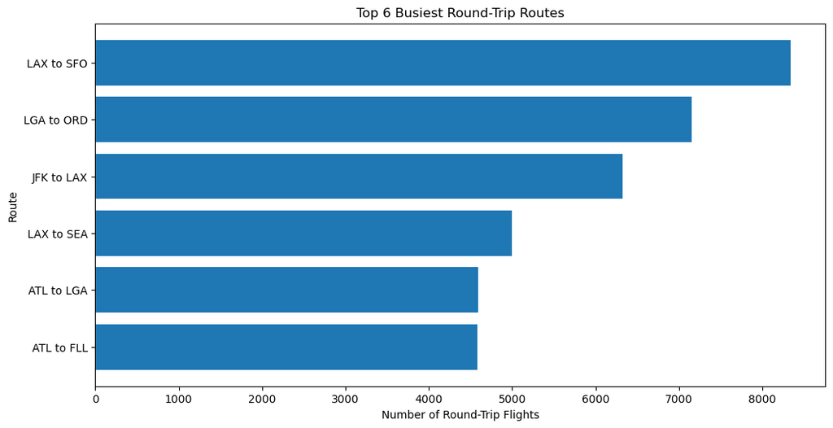

```python
# Separate the route identifier into origin and destination
top_6_round_trips[['ORIGIN', 'DESTINATION']] = top_6_round_trips['Round_Trip_ID'].str.split('-', expand=True)

# Plot a bar chart to visualize the busiest round-trip routes
plt.figure(figsize=(12, 6))
plt.barh(top_6_round_trips['ORIGIN'] + ' to ' + top_6_round_trips['DESTINATION'], top_6_round_trips['Flight Count'])
plt.xlabel('Number of Round-Trip Flights')
plt.ylabel('Route')
plt.title('Top 6 Busiest Round-Trip Routes')
plt.gca().invert_yaxis()  # Invert the y-axis to display the busiest route at the top
plt.show()
```

```python
# Exclude canceled flights
Flights_final_uncancelled2 = Flights_final_merged[Flights_final_merged['CANCELLED'] == 0]

# Define cost components based on provided information
Fuel_maintanance = 8  # Fuel, Oil, Maintenance, Crew cost per mile
Depreciation_insuarance = 1.18 # Depreciation, insuarance, other
fixed_cost_per_airport = {'medium_airport': 5000, 'large_airport': 10000}
delay_cost_per_minute = 75
passengers = 200  # Maximum passengers per plane

# Create a new column to represent a unique round-trip identifier for each route
Flights_final_uncancelled2['Round_Trip_ID'] = Flights_final_uncancelled2.apply(lambda row: '-'.join(sorted([row['ORIGIN'], row['DESTINATION']])), axis=1)

# Calculate the cost for each round-trip route
Flights_final_uncancelled2['COST'] = (Flights_final_uncancelled2['DISTANCE'] * Fuel_maintanance) + \
              (Flights_final_uncancelled2['DISTANCE'] * Depreciation_insuarance) + \
              (Flights_final_uncancelled2['ORIGIN_TYPE'].map(fixed_cost_per_airport)) + \
              (Flights_final_uncancelled2['DESTINATION_TYPE'].map(fixed_cost_per_airport)) + \
              (Flights_final_uncancelled2['DEP_DELAY'].apply(lambda x: max(0, x - 15) * delay_cost_per_minute)) + \
              (Flights_final_uncancelled2['ARR_DELAY'].apply(lambda x: max(0, x - 15) * delay_cost_per_minute))

# Calculate the revenue for each round-trip route
baggage_fee = 70  # total Baggage fee per checked bag
passengers = 200  # Maximum passengers per plane
total_baggage_fee = (0.5 * passengers * baggage_fee)
Flights_final_uncancelled2['REVENUE'] = (Flights_final_uncancelled2['OCCUPANCY_RATE']) * passengers * Flights_final_uncancelled2['ITIN_FARE'] + total_baggage_fee

# Group the data by the unique round-trip identifier and calculate total revenue, total cost, and total flights
route_summary = Flights_final_uncancelled2.groupby('Round_Trip_ID').agg(
    Total_Flights=('FL_DATE', 'count'),
    Total_Revenue=('REVENUE', 'sum'),
    Total_Cost=('COST', 'sum')
).reset_index()

# Calculate profit for each route
route_summary['PROFIT'] = route_summary['Total_Revenue'] - route_summary['Total_Cost']

# Sort routes by profit in descending order
top_6_profitable_routes = route_summary.sort_values(by='PROFIT', ascending=False).head(6)

# Additional Components:
# Calculate summary values for key components and total round-trip flights for the top 6 routes
total_round_trip_flights = top_6_profitable_routes['Total_Flights'].sum()
average_profit = top_6_profitable_routes['PROFIT'].mean()
total_revenue = top_6_profitable_routes['Total_Revenue'].sum()
total_cost = top_6_profitable_routes['Total_Cost'].sum()

# Display the summary of the top 6 most profitable round-trip routes and additional components
print("Top 6 Most Profitable Round-Trip Routes:")
print("\n\n")
print(top_6_profitable_routes)
print("\nSummary of Key Components:")
print(f"Total Round-Trip Flights: {total_round_trip_flights}")
print(f"Average Profit: ${average_profit:.2f}")
print(f"Total Revenue: ${total_revenue:.2f}")
print(f"Total Cost: ${total_cost:.2f}")
```

```
Top 6 Most Profitable Round-Trip Routes:



     Round_Trip_ID  Total_Flights  Total_Revenue    Total_Cost        PROFIT
1670       JFK-LAX           6320   8.587307e+08  2.781494e+08  5.805814e+08
1692       JFK-SFO           3721   4.371931e+08  1.708551e+08  2.663381e+08
1308       EWR-SFO           2424   3.614326e+08  1.124664e+08  2.489663e+08
1795       LAX-SFO           8340   4.364342e+08  2.146654e+08  2.217688e+08
1833       LGA-ORD           7156   4.320897e+08  2.132102e+08  2.188795e+08
143        ATL-LGA           4594   3.194088e+08  1.308356e+08  1.885732e+08

Summary of Key Components:
Total Round-Trip Flights: 32555
Average Profit: $287517866.76
Total Revenue: $2845289175.54
Total Cost: $1120181974.96
```

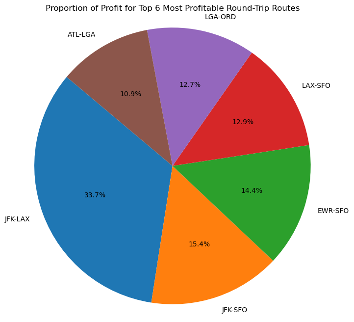

```python
# Extract data for plotting
profits = top_6_profitable_routes['PROFIT']
routes = top_6_profitable_routes['Round_Trip_ID']

# Create a pie chart
plt.figure(figsize=(8, 8))
plt.pie(profits, labels=routes, autopct='%1.1f%%', startangle=140)
plt.axis('equal')  # Equal aspect ratio ensures that pie is drawn as a circle.
plt.title('Proportion of Profit for Top 6 Most Profitable Round-Trip Routes')

# Display the chart
plt.show()
```

**3. The 5 round trip routes that you recommend to invest in based on any factors that you choose. Identify both the origination airport and destination airport for each of the five round trip routes you recommend**

```python
# Step 1: Calculate the average values for specific columns in 'Flights_final_uncancelled2'
average_values = Flights_final_uncancelled2.groupby('Round_Trip_ID').agg(
    Avg_OCCUPANCY_RATE=('OCCUPANCY_RATE', 'mean'),
    Avg_ITIN_FARE=('ITIN_FARE', 'mean'),
    Avg_DEP_DELAY=('DEP_DELAY', 'mean'),
    Avg_ARR_DELAY=('ARR_DELAY', 'mean')
).reset_index()

# Calculate the average profit per flight
top_6_profitable_routes['Average_Profit_Per_Flight'] = top_6_profitable_routes['PROFIT'] / top_6_profitable_routes['Total_Flights']

# Step 2: Merge the average values with 'top_6_profitable_routes' dataset
top_6_profitable_routes_updated = top_6_profitable_routes.merge(average_values, on='Round_Trip_ID', how='left')

# Define the list of routes you want to filter
recommendend_routes = ['EWR-SFO', 'JFK-LAX', 'JFK-SFO', 'ATL-LGA', 'LGA-ORD']

# Filter the DataFrame to get rows with the specified routes
five_recommendend_routes = top_6_profitable_routes_updated[top_6_profitable_routes_updated['Round_Trip_ID'].isin(recommendend_routes)]

# Now, 'top_6_profitable_routes' contains the new columns with average values
print("five_recommendend_routes:")
print("\n")
print(five_recommendend_routes)
```

```
five_recommendend_routes:


  Round_Trip_ID  Total_Flights  Total_Revenue    Total_Cost        PROFIT  \
0       JFK-LAX           6320   8.587307e+08  2.781494e+08  5.805814e+08
1       JFK-SFO           3721   4.371931e+08  1.708551e+08  2.663381e+08
2       EWR-SFO           2424   3.614326e+08  1.124664e+08  2.489663e+08
4       LGA-ORD           7156   4.320897e+08  2.132102e+08  2.188795e+08
5       ATL-LGA           4594   3.194088e+08  1.308356e+08  1.885732e+08

   Average_Profit_Per_Flight  Avg_OCCUPANCY_RATE  Avg_ITIN_FARE  \
0               91864.141547            0.650074     991.483806
1               71577.013973            0.649852     849.588288
2              102708.866672            0.649905    1090.630100
4               30586.846647            0.649124     411.228737
5               41047.710002            0.651110     480.990433

   Avg_DEP_DELAY  Avg_ARR_DELAY
0       8.546044      -1.890300
1      15.353937       6.883784
2      21.497112      14.535462
4      21.337060      19.644836
5      11.304528       5.457834
```

**The 5 roundtrip routes recommended**

I would recommend the following five routes.I placed a lot of weight on the average profit per flight because as a new investor the company is looking to recoup the huge capital investment and they would need to break even soon.

   When assessing the profitability of a route, it's crucial to look not only at the total profit but also at the average profit per flight. A route with a high total profit but many flights may still result in relatively low average profit per flight especially since these total profits are distributed between the different carriers operating within that route meaning that the profit each carrier gets at the end might not be much.

If a route has numerous flights, it can indeed contribute significantly to the total profit, but the per-flight profitability may be lower. On the other hand, a route with fewer flights but higher average profit per flight may provide more sustainable and lucrative opportunities for the airline.

It's a good practice to analyze both total profit and average profit per flight to make informed investment decisions. Routes with a balance of high total profit and reasonable average profit per flight may be the most attractive for the airline, as long as they align with the company's strategy and competitive advantage in punctuality.

Some of the flight_routes suggested also have some arrival and depature delays though not too high and the company can use the competitive edge of punctuality to gain a good market share.

[figure not shown]

```python
# Extract data from the DataFrame and convert them into lists
five_recommendend = five_recommendend_routes['Round_Trip_ID']
five_recommendend_routes_sorted = five_recommendend_routes.sort_values(by='Average_Profit_Per_Flight', ascending=False)
avg_profits_for_flight = five_recommendend_routes_sorted['Average_Profit_Per_Flight']

# Create an area plot for average profit per flight
plt.figure(figsize=(10, 6))
plt.stackplot(five_recommendend, avg_profits_for_flight, labels=['Average Profit Per Flight'], alpha=0.7)
plt.xlabel('Route')
plt.ylabel('Average Profit Per Flight ($)')
plt.title('Average Profit Per Flight for the 5 Recommended Routes')
plt.legend()

# Show the area plot
plt.show()
```

**4. The number of round-trip flights it will take to breakeven on the upfront airplane cost for each of the 5 round trip routes recommended.**

```python
# Define the upfront airplane cost
upfront_airplane_cost = 90000000  # $90 million

# Calculate the number of flights to break even for each route
five_recommendend_routes['Flights_to_Break_Even'] = upfront_airplane_cost / five_recommendend_routes['Average_Profit_Per_Flight']

# Order the final table by 'Flights_to_Break_Even' from least to most
five_recommendend_routes = five_recommendend_routes.sort_values(by='Flights_to_Break_Even')

# Print the results
print("The 5 Recommended Round-Trip Routes:")
print("\n\n")
print(five_recommendend_routes)
```

```
The 5 Recommended Round-Trip Routes:



  Round_Trip_ID  Total_Flights  Total_Revenue    Total_Cost        PROFIT  \
2       EWR-SFO           2424   3.614326e+08  1.124664e+08  2.489663e+08
0       JFK-LAX           6320   8.587307e+08  2.781494e+08  5.805814e+08
1       JFK-SFO           3721   4.371931e+08  1.708551e+08  2.663381e+08
5       ATL-LGA           4594   3.194088e+08  1.308356e+08  1.885732e+08
4       LGA-ORD           7156   4.320897e+08  2.132102e+08  2.188795e+08

   Average_Profit_Per_Flight  Avg_OCCUPANCY_RATE  Avg_ITIN_FARE  \
2              102708.866672            0.649905    1090.630100
0               91864.141547            0.650074     991.483806
1               71577.013973            0.649852     849.588288
5               41047.710002            0.651110     480.990433
4               30586.846647            0.649124     411.228737

   Avg_DEP_DELAY  Avg_ARR_DELAY  Flights_to_Break_Even
2      21.497112      14.535462             876.263198
0       8.546044      -1.890300             979.707626
1      15.353937       6.883784            1257.386904
5      11.304528       5.457834            2192.570548
4      21.337060      19.644836            2942.441274
```

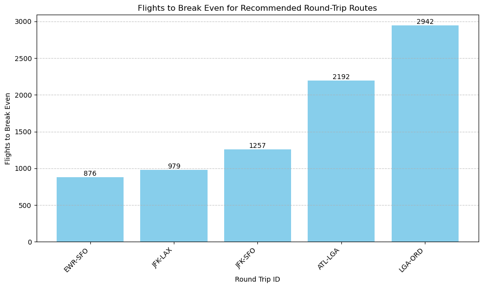

```python
# Recommended routes and their corresponding Flights_to_Break_Even values
routes = five_recommendend_routes['Round_Trip_ID']
flights_to_break_even = five_recommendend_routes['Flights_to_Break_Even'].astype(int)  # Convert to integers

# Create a vertical bar chart
plt.figure(figsize=(10, 6))
bars = plt.bar(routes, flights_to_break_even, color='skyblue')
plt.xlabel('Round Trip ID')
plt.ylabel('Flights to Break Even')
plt.title('Flights to Break Even for Recommended Round-Trip Routes')
plt.xticks(rotation=45, ha='right')
plt.grid(axis='y', linestyle='--', alpha=0.7)

# Add labels with the actual figures (integers) on top of the bars
for bar, value in zip(bars, flights_to_break_even):
    plt.text(bar.get_x() + bar.get_width() / 2, value, str(value), ha='center', va='bottom')

# Show the vertical bar chart
plt.tight_layout()
plt.show()
```

**5. Recommended Key Performance Indicators (KPI’s) to track in the future to measure the success of the round-trip routes recommended.**

To measure the success of the recommended round-trip routes, you should track several Key Performance Indicators (KPIs). Here are some KPIs that I recommend monitoring:

**Profit Margin:** Calculate the profit margin for each route, which is the percentage of profit relative to total revenue. A higher profit margin indicates a more successful route.

**Occupancy Rate / load factor:** Continuously track the average occupancy rate of flights on each route. A higher occupancy rate means that more seats are filled, leading to increased revenue.

**Flight Punctuality:** Monitor on-time performance, specifically the percentage of flights that depart and arrive on time. Higher punctuality enhances customer satisfaction and may attract more passengers.

**Customer Satisfaction:** Collect feedback from passengers to measure their satisfaction with the service. Happy customers are more likely to become repeat customers and refer others.

**Marketing and Promotion:** Evaluate the effectiveness of marketing and promotional campaigns for each route. Track the return on investment (ROI) for these activities.

**Route-Specific Costs:** Continuously assess the costs specific to each route, including fuel, maintenance, crew, and airport fees. Identify cost-saving opportunities.

**Market Demand:** Keep an eye on changes in market demand. If there's a shift in passenger preferences or if new competitors enter the market, adapt your strategy accordingly.

**Price:** Adjust pricing strategies based on demand and competition. Ensure that fare structures are optimized to maximize revenue.

**Competition:** Regularly analyze the competitive landscape on each route. Monitor the actions of competitors and respond accordingly.

**Operational Efficiency:** Monitor operational efficiency, such as aircraft turnaround time, to minimize delays and reduce costs.

**Customer Acquisition Costs:** Calculate the cost of acquiring each customer on a specific route. This can help assess the effectiveness of marketing efforts.

**Financial Performance:** Keep a close eye on financial performance, including cash flow, return on investment, and net profit, for each route.

These KPIs will provide an overview of the success of the recommended round-trip routes and help make informed decisions to improve profitability and customer satisfaction. Regularly reviewing and analyzing these metrics will be crucial for route management and decision-making.

## SUGGESTIONS OF FURTHER WORK

- If i had more time i would provide better visualizations in tableau maybe add a map of the US showing the various routes of interst
- I would also maybe do a more extensive analysis above the questions that were asked in this data challenge
- Also i would maybe compute more metrics to help in decision making like profit per mile etc.
- I would also have prepared a separate document to present my insights and recommendations without the code.
- I would also do a bit more research into the airline industry to understand more about the industry e.g what metrics they use, what factors are important to them etc so that i can give more informed recommendations.